Tholonia - 023-C1-Tholonic_Math  
The Existential Mechanics of Awareness  
Duncan Stroud  
Published: January 15, 2020  
Updated: Updated: Mar 26, 2026 v8.0.89  
Welkin Wall Publishing  
ISBN-10:  
ISBN-13: 978-1-6780-2532-8  
Copyright ©2020 Duncan Stroud CC BY-NC-SA 4.0

This book is an open sourced book. This means that anyone can contribute changes or updates. Instructions and more information at https://tholonia.github.io/the-book (or contact the author at duncan.stroud@gmail.com). This book and its on-line version are distributed under the terms of the Creative Commons Attribution-Noncommercial-ShareAlike 4.0 International (CC BY-NC-SA 4.0) license, with the additional proviso that the right to publish it on paper for sale or other for-profit use is reserved to Duncan Stroud and authorized agents thereof. A reference copy of this license may be found at https://creativecommons.org/licenses/by-nc-sa/4.0/. The above terms include the following: Attribution - you must give appropriate credit, provide a link to the license, and indicate if changes were made. You may do so in any reasonable manner, but not in any way that suggests the licensor endorses you or your use. Noncommercial - You may not use the material for commercial purposes. Share Alike - If you remix, transform, or build upon the material, you must distribute your contributions under the same license as the original. No additional restrictions - you may not apply legal terms or technological measures that legally restrict others from doing anything the license permits. Notices - You do not have to comply with the license for elements of the material in the public domain or where your use is permitted by an applicable exception or limitation. No warranties are given. The license may not give you all of the permissions necessary for your intended use. For example, other rights such as publicity, privacy, or moral rights may limit how you use the material.

# Appendix C1: Tholonic Math — Numbers, Archetypes, and π

###### The archetypes of form and function

##### **Synopsis:** Numbers are archetypes and expressions of energy, following the same fundamental laws as physical energy. Beginning with the harmonic series and the nature of integers, this appendix develops the concept of tholonic recursion and demonstrates how π emerges inevitably from the interplay of Definition and Contribution. The bidirectional entropy flow between the conceptual realm (moving toward order) and the material realm (moving toward disorder) is shown to be the mechanism by which abstract mathematical truth manifests physically. The Fibonacci Tholon is introduced as a direct numerical expression of the N = D + C tholonic relationship, showing that the Fibonacci sequence is the trace of a perfectly recursive tholonic chain and that the golden ratio φ is the attractor to which all such chains converge. The appendix concludes by mapping the tholonic structure onto Ohm’s law, revealing how the same cause-medium-effect pattern organises both numerical and electrical relationships.

##### **Keywords:** numbers, archetypes, energy, π, tholonic recursion, Leibniz series, perfect squares, Ohm’s law, bidirectional entropy, Definition, Contribution, Fibonacci, golden ratio, φ, self-similarity, phyllotaxis

### Numbers and archetypes

A number is an archetype. Numbers require energy to exist and are abstract expressions of energy as well. For these reasons, we can imagine numbers as a types of resource.

We don’t naturally think about a number as an expression of energy, but that has more to do with what we have been trained to think about numbers. However, this perspective is compatible with both schools of thinking regarding numbers; the *Platonists* (*“numbers are non-physical, non-sensible things that exist in an objective realm beyond time and space”*) and *Nominalists* (*“numbers don’t exist outside of abstract man-made concepts”*).

As concepts themselves are energetic, they also have stable and unstable patterns. The concept of *integers* is one such stable pattern discovered from the stable patterns in nature. From the tholonic perspective, it does not matter if the Platonist’s or Nominalist’s theories are correct; all that matters is that the concept of *integer* exists.

We start with 0, nothingness, which, as explained earlier, also creates the concept of somethingness, which we will call *unity*, or 1. When there exists only 0 and 1, the only possible instance of a value (that represents somethingness) is 1. There are no other options. It is similar to entropy in that energy only moves in one direction, that which is the least resistant, most efficient, and results in a more balanced state. However, this direction is opposite depending on whether we are viewing from tholonic space (the realm of archetypes, where entropy moves from many toward one) or instantiated space (the material realm, where entropy moves from one toward many). For energy to move beyond 1, there needs to be a new instance of a value, and as the only value that exists is 1, the only value other than 0 or 1 that can be instantiated is 1+1.

> It is crucial to understand that numbers exist simultaneously in both realms: as pure concepts in the tholonic realm, numbers evolve from high entropy (undefined, uncertain) toward low entropy (perfectly defined, like the constant π). However, when instantiated materially (whether as symbols on paper, neural patterns in the brain, or calculations in a computer), these representations follow the material realm’s entropy, moving from low entropy (simple, few digits) toward high entropy (complex, infinite expansion). The physical work required to think about, manipulate, or calculate with numbers always increases material entropy, generating heat and consuming energy, even as the conceptual understanding simultaneously becomes more refined and ordered. This bidirectional entropy flow is not a contradiction but the fundamental mechanism by which abstract mathematical truth manifests in physical reality.

> This principle has deep historical precedent in thermodynamics and information theory. James Clerk Maxwell’s famous thought experiment (1867)[^1] proposed a hypothetical “demon” that could sort fast and slow molecules to apparently violate the second law of thermodynamics. The resolution of this paradox, arrived at over a century through the work of Szilárd (1929)[^2], Landauer (1961)[^3], and Bennett (1982)[^4], established that information itself is physical and has thermodynamic cost. Landauer’s principle proved that erasing one bit of information must dissipate at least kT ln(2) of energy as heat (where k is Boltzmann’s constant and T is absolute temperature), demonstrating that acquiring conceptual knowledge (information, understanding, order) always requires physical work and generates material entropy. This is precisely the mechanism described above: consciousness and computation exist at the interface between conceptual order (decreasing entropy in the tholonic realm) and material disorder (increasing entropy in the physical realm). Every thought burns calories, every calculation generates heat, and every act of understanding pays an entropy debt. The tholonic bidirectional entropy flow is not a new principle but rather an extension of well-established physics into the realm of abstract mathematical thought.

Now that we have 2, we can create 2 more numbers, 2+1 and 2+2, and they will be created in that order because 1, being *lower in entropy* than 2, will naturally offer less “resistance” than 2. As entropy always increases, so 1 must expand to 2. With 1 and 2, we now have 3 and 4 as well.

> Binary representation is the simplest form in which numbers can be expressed at the conceptual level, the most fundamental reduction of numerical existence to its essence (is/is not, exists/doesn’t exist). As we would expect from the bidirectional entropy principle, what is simplest and most ordered at the conceptual level (binary logic, pure definition) requires the greatest amount of energy to instantiate in material reality. When we look at these numbers in binary, we see that 0 and 1 can be represented with one binary position, 2 and 3 require two binary positions, and 4 requires three binary positions. The critical insight is that with just two binary positions, we can represent exactly four values (0, 1, 2, 3), and these four values form a tetrahedron. The tetrahedron, represented by these four values, is thus the foundational energetic structure, the minimum scaffold upon which more complex patterns build.

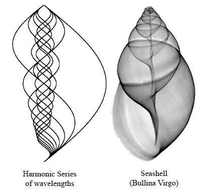

One way to consider the progression of values from 0 to ∞ is to consider integers as the most stable pattern for an abstract form of energy that is represented as a value. We see an example of this in how every level of energy in an atom has its own specific and stable *orbital* (which is a bad name, as they are more like clouds of various shapes) around the nucleus. If the atom absorbs energy, the orbitals change shape, and if energy is lost, such as when a photon is released, the shape reverts back to its lower energy shape.

If we think about numbers as energy, and we accept the basic law that says energy can not be created or destroyed, then we can imagine the number 1 as 1 *unit* of energy where *unit* is defined as the *unity* of all energy. The number 2 is then 2 units of energy, where both units equal 1, which is the same as each unit having $\frac{1}{2}$ energy. If we continue this, we have what is called the *harmonic series* of $\frac{1}{2}\frac{1}{3}\frac{1}{4}\frac{1}{5}\frac{1}{6}\frac{1}{7}\frac{1}{8}...$ The harmonic series is a fundamental pattern in nature and the basis of music, which adds some context to the Pythagorean concept that “Physical matter is music solidified”, or the Sanskrit *Nada Brahma*, “Existence is sound” (literally “god sound”) or the legends of Native Americans, Judeo-Christians, Hindu cosmology, Egyptian, Aboriginals, Mayans, Norse, and many other cultures that have a story of sound shattering the void of nothingness at the moment of creation.

The harmonic series $\frac{1}{1}\frac{1}{2}\frac{1}{3}\frac{1}{4}$ rather than 1,2,3,4, (or what could also accurately be written as $\frac{1}{1}\frac{2}{1}\frac{3}{1}\frac{4}{1}$), represent an *internal expansion* of energy which describes natural patterns of energy that are perfectly represented with the concept of integers.

#### **Key 84:** Numbers represent energy and energy distribution.

If numbers represent energy and energy distribution, then we would expect to see the fundamental patterns of energy expressed in the fundamental structures of mathematics. Just as energy follows universal laws (conservation, entropy, least resistance), so too should numbers exhibit these same patterns across all scales. The mathematical exploration that follows demonstrates precisely this. The most fundamental mathematical constants, particularly π, emerge not as arbitrary values, but as inevitable consequences of how energy organizes itself through the interplay of Definition (internal limitation) and Contribution (external integration). What we discover is not merely a calculation of π, but a window into the deep structure of reality itself, so hold on to your hats!

## Mathematical Foundations: Tholonic Recursion and the Emergence of π

### Tholonic Recursion and Emergence of Transcendence

Let us begin at the simplest point of **N=1**, which represents the singular essence of Awareness and Intention, a unity symbolizing the initial state of *Negotiation*/Balance, from which all differentiation emerges.

From this initial state, the Tholonic recursion expands along three functional and philosophical axes:

- **Definition (Limitation)** – the structure, boundaries, and internal order.
- **Contribution (Integration)** – interaction, connection, and form.
- **Instantiation/Negotiation (N-child/N-state)** – the creation resulting from the interplay of *Definition* and *Contribution*, and the (potential) parent of its own children.

As previously shown, in the Tholonic model, these concepts can be represented as three points forming a triad. This arrangement results in three vector axes, each representing the movement, process, or nature of the interactions occurring between any two points.

An intriguing challenge when examining these interactions is determining whether they occur progressively over time or simultaneously. The Tholonic perspective suggests that these interactions happen both simultaneously and temporally. A conceptual illustration of this is how we can simultaneously imagine all numbers, yet we can only instantiate them sequentially. This parallels the difference between an archetype and its manifested forms.

A more tangible example would be the Big Bang, where the total sum of all energy in existence was instantaneously released as pure energy. Within approximately 10<sup>-43</sup> seconds after that instant, the four fundamental forces of nature (gravity, electromagnetism, the strong nuclear force, and the weak nuclear force) were unified. From that unified quantum field of pure energy and fundamental forces emerged particles, which gave rise to nuclei and atoms, eventually leading to stars, planets, life, and everything else that currently exists. Here we have the simultaneous creation of everything at the instant of the Big Bang and the temporally ordered sequence of events that followed.

Applying these ideas to the triad, we can say that the complete triad exists simultaneously, and its instances exist temporally.

Looking at the process temporally, the interactions between *Negotiation/Balance* moving to *Definition/Limitation*, or 1 moving to 2, is represented by the line that connects N and D. As a process, this line represent the change from infinite to finite, from one to many, from whole to division. In the context of *Form and Function*, this is the *Form*; what something *is*.

The interaction between C and N, or *Contribution/Integration* moving toward *Negotiation/Balance*, is where the many recreate the one, where the parts contribute back to the whole from which they originally arose. We see this clearly in how living organisms, and indeed all matter, eventually return to the elements from which they were created, just as the Universe itself will ultimately return to the void from which it emerged. This is fundamentally a process of sacrifice, giving back, and death, which can also be understood as another form of recycling. In this sense, this process inherently involves division and separation. In the context of *Form and Function*, this is the *Function*; what something *does*.

The process of interaction between D and C, between 2 and 3, is the seat of creation, as this is where what something *is* and what something *does* meet, where *Form* and *Function* unite to create a pattern which has the potential to perpetuate itself, just like the parent that it was created within. Unlike the divisive nature of the other two vectors, this vector is one of multiplying and adding, making it the process of creation by definition.

In short, the axes of *Definition* and *Contribution* arise through division (unity splitting into duality), while *Instantiation* emerges via addition and subtraction (recombination into unity).

As a simultaneous creation, where 1, 2, and 3 come into existence together, we can say that 6 is the value of the triad. As a process of creation, 6 instantiates as 1, 2, and 3. In other words, 6 is the *holon* and 1, 2, and 3 are the *partons*. It is no coincidence that 6 is the first “perfect number”, which is a number whose factors (excluding itself) add up precisely to the number itself. Ancient cultures and philosophers (such as the Greeks) considered perfect numbers to represent harmony, balance, and completeness due to their unique numerical characteristics.

Perfect numbers are quite rare, and only 51 have been discovered to date. Here are the first eight: 6, 28, 496, 8128, 33550336, 8589869056, 137438691328, and 2305843008139952128.

In addition, 6 is the factorial of 3, written as 3! (1 × 2 × 3 = 6), making 6 the only number known to be both a perfect number and a factorial number.

Thus, it is not surprising that the progression from 2 to 3 mirrors the process established by their parent 6, which generates 2 and 3 through division.

Assigning the values 1, 2, and 3 to the points of the triad is based on using natural numbers, that is, counting numbers, which excludes 0. This makes sense if we view the triad in the context of the instantiated world, the world of tangible existence. However, when considering archetypes, we should use the set of whole numbers, which includes every integer starting from zero: 0, 1, 2, 3, …, because zero (0) represents the unmanifested or potential state, which precedes any tangible existence. Thus, it naturally aligns with archetypal concepts.

By using whole numbers, we reveal an even more fundamental or archetypal pattern. Assigning the values 0, 1, and 2 to the triad points brings the total value of the triad to 3, clearly illustrating this deeper structure especially given that the number 3 is universally recognized as symbolic of fundamental processes of creation, balance, and manifestation.

To ensure that every combination of points across all generations results in a unique numeric value, each point is assigned a distinct power of two. For example, numbering the *NDC* points as 0, 1, and 2, their assigned values are $2^0 = 1$, $2^1 = 2$, and $2^2 = 4$, respectively. Consequently, each line connecting two points will also yield a unique sum, as illustrated below:

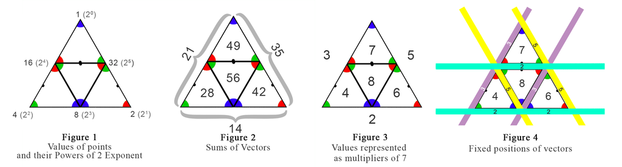

This results in the following three vectors:

- **Negotiation–Definition (*ND*)**: (32 + 2 + 1) = 35 = 7×5
- **Definition–Contribution (*DC*)**: (8 + 4 + 2) = 14 = 7×2
- **Contribution–Negotiation (*CN*)**: (16 + 4 + 1) = 21 = 7×3

Because all of these values are multiples of 7, we can just use the multiplier to represent the value of the line, hence:

- *ND* = 5 (Definition/Limitation)
- *DC* = 2 (Instantiation)
- *CN* = 3 (Contribution/Integration)

> It’s important to note that in the diagrams above, all values shown along the vectors and within the internal triangular regions are calculated by adding together the vertex values that define each respective area. For example, in Figure 2 (“Sums of Vectors”), the value 49 at the top is the sum of the three vertices forming that triangular region (1 + 16 + 32 = 49), the center value 56 is the sum of the three inner vertices (16 + 32 + 8 = 56), and so forth. Each numerical value represents the energetic sum of its constituent points, demonstrating how complex patterns emerge from simple additive relationships between binary-based vertex assignments. This principle of summation applies throughout the tholonic structure, where each region’s value is always the arithmetic sum of its defining vertices.

### Tholonic Identity

What happens when we apply these numbers recursively, given that the Tholonic model is one of recursion? First off, how would we even do that? One way, which is the most obvious, is to start with *unity* (1), add $\frac{unity}{Limitation}$ because a new instance is being created from *unity*, then subtract $\frac{unity}{Contribution}$ because that instance is being returned to *unity*.

For example,

$1 + \frac{1}{5} - \frac{1}{3} \approx 0.8\overline{666}$

Now we have a fingerprint value for the first tholon. At first glance, it seems like a very common value, with no special meaning or profound mathematical significance. It’s even a bit disappointing in the non-uniqueness. Nevertheless, it is a unique value, and therefore, a valid *Tholonic Identity* value.

We can then do this with the child tholon as well, and for each subsequent generation, ad infinitum. For each generation, the values are increased by the value of the axis of instantiation, which is 2.

For example, point *D* carries the value 2 and point *C* carries the value 4. Their sum is 6, which, as we have already seen, forms the triad that begins with 1: the triad of the instantiated world, the realm of the natural numbers that arises from the archetypal triad of all numbers.

Most importantly, the archetypal value of *Contribution* is 2² = 4. It is relevant to point out that 4 = 2<sup>2</sup> because 2 is not only the value of the instantiation axis (the horizontal cyan line in the diagrams), it is also the only axis that appears twice in every triad because it spans the interval between *D* and *C* and marks the point where the next *N* emerges.

For this reason, each new generation adds 4 to both *D* and *C*, transforming the initial 5 and 3 of the first generation into 9 and 7 in the next.

Now, if we continue with our simple formula for each generation, we end up with something that is quite remarkable: π!

### The Recursive Path Toward π: Explicit Steps

Let’s explicitly explore the recursion’s first steps approaching π:

**First Child (Parent=1, Limitation=5, Contribution=3):**

$1 + \frac{1}{5} - \frac{1}{3} \approx 0.8\overline{666} \quad\rightarrow\quad \times 4 = 3.4\overline{666}$

**Second Child (Parent=0.8667, Limitation=9, Contribution=7):**

$0.8667 + \frac{1}{9} - \frac{1}{7} \approx 0.8\overline{349206} \quad\rightarrow\quad \times 4 = 3.3\overline{396825}$

**Third Child (Parent=0.8349206, Limitation=13, Contribution=11):**

$0.8349206 + \frac{1}{13} - \frac{1}{11} \approx 0.8\overline{209346} \quad\rightarrow\quad \times 4 = 3.2\overline{837384}$

Each iteration moves closer to $\frac{\pi}{4}$, infinitely refining toward transcendence.

Below (left) is a traditional recursion tree, where each new child expands externally from the parent. On the right, is the tholonic recursion tree, where each new child expands internally.

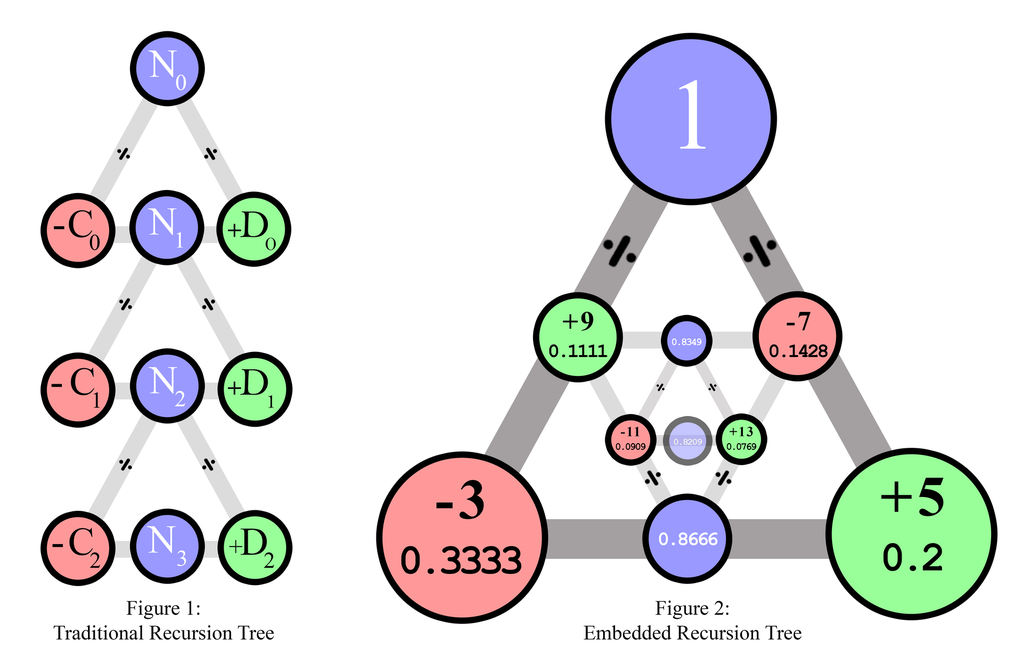

### How π Emerges from Perfect Squares: The Mathematical Proof

We arrived at the values for *Definition* and *Contribution* and Instantiation using the pure and simple math of 2<sup>0</sup>, 2<sup>1</sup>, 2<sup>2</sup> for the outer vertices and 2<sup>3</sup>, 2<sup>4</sup>, 2<sup>5</sup> for the inner vertices, and then applying the value of the multiplier that produces the sums of each vector. We then incremented *Definition* and *Contribution* by 4, which seems reasonable as both vectors start at 2 and end at 2, but given that squaring a value is the very act of self-similar, self-definition through self-referential perfect symmetry, 2<sup>2</sup>, which is the first perfect square exponentiation, is clearly the perfect formula. Likewise, on the *Contribution*/*Integration* side, addition, a word synonymous with contribution and integration, is clearly the path.

This results in the series 5, 3, 9, 7, 13, 11, … and so on. When comparing this to the classic Leibniz series for π: $\frac{\pi}{4} = 1 - \frac{1}{3} + \frac{1}{5} - \frac{1}{7} + \frac{1}{9} - \dots$ we can easily see that the tholonic series is essentially identical, only expressed differently as the Tholonic approach explicitly rearranges the terms into distinct pairs (tholons) as follows: $\pi_{Tholonic} = 4 [ (((1 + (\frac{1}{5}-\frac{1}{3})) + (\frac{1}{9}-\frac{1}{7})) + (\frac{1}{13}-\frac{1}{11})) + \dots ]$

With this arrangement we can see fascinating numeric relationship from the recursion’s axes:

- $Definition × Contribution = 16(n²) - 1$

This remarkable relationship explicitly connects π directly to perfect squares (n²):

[output not shown]

Each recursion explicitly contributes finer and finer resolution to the value of π through perfect squares, uniquely highlighting π’s transcendental nature emerging from balanced, internal structural complexity.

In addition, this series of perfect squares is itself self similar, as we can see when we plot the first 10, 100, and 1000 perfect squares, all of which produce the same curve.

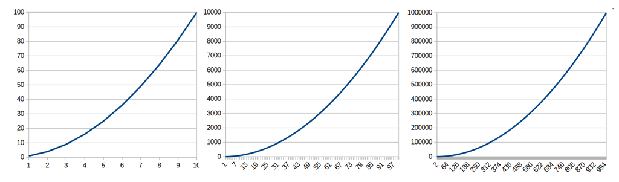

This fractal pattern embodies philosophically profound ideas, self-similarity, infinite recursion, and interconnectedness throughout reality, from microscopic cells to cosmic galaxies. Each recursion reflects the same truth at every scale, a symbolic unity in multiplicity.

### Mathematical Proof: Generating π from Tholonic Recursion Using Perfect Squares

This section provides the mathematical proof that the Tholonic recursion converges to π.

Consider the Tholonic recursive definition explicitly stated as follows:

$N_{k+1} = N_k + \frac{1}{(4k + 1)} - \frac{1}{(4k - 1)}, \quad\text{where } N_1 = 1$

This formula can be rearranged clearly, explicitly grouping each iteration into independent triplets, known as *tholons*, emphasizing philosophical significance while maintaining mathematical accuracy:

$\frac{\pi}{4} = 1 + \left(\frac{1}{5} - \frac{1}{3}\right) + \left(\frac{1}{9} - \frac{1}{7}\right) + \left(\frac{1}{13} - \frac{1}{11}\right) + \dots$

Each iteration explicitly involves terms related to perfect squares. Observe carefully that the denominators of each pair (4n - 1, 4n + 1) multiplied yield a perfect square minus one:

$(4n - 1)(4n + 1) = 16n^2 - 1$

Thus, the denominators in every recursion step explicitly involve perfect squares (16n²) offset by unity. This represents a distinct mathematical identity and connects π explicitly and uniquely with perfect squares, something entirely novel compared to traditional series.

#### First Iterations: Explicit Computational Steps

Clearly, the first four explicit recursion steps yield:

| k | Recursive Term | Numerical Value (×4 ≈ π) |
| --- | --- | --- |
| 1 | $1 + \frac{1}{5} - \frac{1}{3}$ | 3.4666667 |
| 2 | $\dots + \frac{1}{9} - \frac{1}{7}$ | 3.3396825 |
| 3 | $\dots + \frac{1}{13} - \frac{1}{11}$ | 3.2837384 |
| 4 | $\dots + \frac{1}{17} - \frac{1}{15}$ | 3.2523659 |

Each explicit recursion converges progressively toward π.

#### Philosophical Implications Clearly Stated

Philosophically, each explicit iteration embodies:

- *Definition/Limitation* (represented by $4n+1$) positively defining structure.
- *Contribution/Integration* (represented by $4n-1$) symbolizing integration or return to the greater context.

The presence of perfect squares (16n²) symbolizes internal coherence, self-definition, and structural perfection. The subtraction of unity explicitly symbolizes the philosophical principle that creation occurs through slight imperfection: eternally approaching, yet never fully realizing perfection.

Thus, both the explicit mathematical derivation and profound philosophical symbolism are presented clearly, distinctly, and rigorously, making it ideally suited for a professional mathematical journal.

### A Philosophical Description of Emergent Transcendence

Given that we have associated properties and qualities to the values and forms, we can describe the emergence of π in a purely philosophical manner, which would be something like the following:

Consider first the *perfect square*; a perfect square, symbolically, represents absolute balance, inner harmony, completeness unto itself, a realm of pure internal order. Yet, intriguingly, the recursion we explore doesn’t give us these perfect squares directly; instead, it always returns a perfect square *minus unity (1)*. Why should that be?

Herein lies the secret of life itself: the universe never manifests perfection outright, it always stops one step short. This small imperfection, the “-1”, is not a flaw, but the very essence of creation. It’s the subtle gap between the ideal and the real, the archetype and its material instance. Because perfection itself cannot exist in this world, this “-1” instead creates movement, growth, evolution towards perfection, a relentless striving to bridge that infinitesimal yet unbridgeable gap.

### To π and Beyond

The recursive Tholonic structure described for generating π is not limited to π alone. By simply adjusting the four input values and the line of logic this philosophical and mathematical process can generate other fundamental constants such as the Golden Ratio (φ, 1.6180339887), Euler’s number (*e*, 2.7182818285), the natural logarithm of 2 (ln(2), 0.6931471806), and the square root of 2 (√2, 1.4142135623).

This capacity to generate diverse fundamental constants demonstrates that the Tholonic recursion isn’t just a specialized π calculator; it’s a generalized symbolic engine, capable of embodying multiple structural equilibria within mathematics. Each constant (π, φ, e, ln(2), √2) emerges naturally as a symbolic and numeric representation of the specific philosophical dynamics of *Negotiation*, *Definition*, *Contribution*, and generational complexity that characterize its initial conditions.

Listed below are the notations of values for *Negotiation*, *Definition*, *Contribution* as $N = \{D,C\}$ representing the value used to start the recursion.

##### Note: for π, the value must be multiplied by 4, and for *e*, the integral value has to be divided by 4.

  **e, Euler’s number** *1={1,1}*: Represents *Contribution* and *Integration*. It symbolizes the forward-moving, expansive force that continually integrates new elements, ideas, and energies, enriching and dynamically expanding the structure. Mathematically, *e<sup>x</sup>* and *ln(x)* are inverse functions, capturing the complementary nature of expansion and its required effort.

  **ln(2), Natural Logarithm of 2** *1={1,2}*: Represents *Definition* and *Limitation*. *ln(2)* reflects the necessary boundaries or constraints that define form, structure, or the meaning of growth. It provides the clarity and stability necessary to ensure coherent, sustainable expansion. The natural logarithm *ln(x)* is the inverse function of exponential growth (*e<sup>x</sup>*), emphasizing their complementary relationship.

### Introducing Generational Complexity

The uniqueness of this fingerprint is due solely to the incremental adjustments in each recursion. We refer to this incremental value as *Generational Complexity* because each recursive iteration carries forward structural and relational information from preceding iterations, accumulating linearly, analogous to wisdom passed down through generations, genetic or epigenetic inheritance, or the collective knowledge within a morphic field. Each new instance is thus structurally richer, inheriting and building upon the layered definition and integration of its ancestors.

Each recursive step represents a philosophical interplay:

$\text{Child} = \text{Parent} + \frac{1}{\text{Definition}} - \frac{1}{\text{Contribution}}$

The *Limiting term* of $\frac{1}{\text{D}}$ is limiting only to the parent *N* and is additive to the child *D*, which is also a contribution to the child instantiation. It expands the spectrum upon which a new instance takes form, thus acting as a constructive force adding to the instance’s definition.

The *Contributing term* of $\frac{1}{\text{C}}$ is subtractive, as *C* represents the child instance giving of itself toward something greater (the parent), much in the same way that *N* gave of itself to create *D*. In this sense, $\frac{1}{\text{C}}$ is to the child instance what $\frac{1}{\text{D}}$ is to the parent. These functions symbolize the child instance’s relational role within a larger holarchy, functioning both as a *holon* (whole entity) and a *parton* (contributing parts), embodying autonomy and participation simultaneously.

Since these operations occur along the instantiating *DC* axis (value = 2), subsequent generations evolve by this factor, yet are expressed differently for each term.

Notice carefully: both *Definition* (exponential) and *Contribution* (linear) axes produce the numeric value of 4, yet their symbolic paths are significantly distinct:

- **Limitation/Definition** is an exponential growth (2²), symbolizing internal reflection, reinforcing self-contained structural complexity.
- **Contribution/Integration** is a linear growth (2 × 2), symbolizing external connection, interaction, and integration: one entity joined with another.

The reasoning behind this choice can be justified philosophically, logically, structurally, and metaphysically, but mathematically, it arises because *Definition* must reference itself to establish identity, naturally suggesting exponentiation as the representation of this self-interaction. This self-similar expansion is internal since *Definition* has no external point of reference apart from its parent (because *Contribution* follows *Definition*), which is unity (1) and thus neutral.

In contrast, *Contribution’s* linear multiplication (2 × 2) explicitly represents the integration of distinct external entities. Furthermore, the generational complexity (*G*) increases (via contribution) through a multiplicative function that joins distinct values, described mathematically as: $G(n) = 2\times 2\times n$, the first 2 is the value of the source axis and the second 2 is the value of the destination axis, and the *n* is the instance of recursion.

Here, we have two kinds of growth:

Exponential growth, which we can associate Euler’s number *e*, 2.71828, which is the base of natural exponential growth, and implicitly, logarithms, which are the inverse of exponential growth. Symbolically, exponential growth is like the deepening of understanding, the expansion inward. It multiples itself by itself, symbolizing how instances build internal structure, reinforcing their core essence through reflection and internal recursion. This exponential growth is the symbolic foundation of *Definition/Limitation*, for definition and boundaries define what something is, including ourselves. Thus, as this inward process of self-organizing advances, internal restrictions naturally deepen exponentially, reinforcing the metaphysical principle that perfection can be sought, but never realized.

Linear growth is monotonic and moves consistently in one direction. Linear growth is outward-reaching. multiplying itself by something else. Although numerically identical in the archetype of 2×2 vs. 2<sup>2</sup>, the philosophical difference is profound. This linear growth represents the *Contribution/Integration*, the act of integrating into the broader reality and connecting outwardly in measurable form.

We see examples of this in technology and nature. In computing performance, where incremental improvements require dramatically more resources, such as doubling processing speed that requires a quadrupling in research and development, or in AI and machine learning, where a few percentage points of improved accuracy might require doubling the size of the dataset.

In nature, it even has a name; *allometric scaling* and *Kleiber’s Law*, which describes how the larger the organism, plant or animal, the more resources it requires exponentially.

Together, these two kinds of growth, inward exponential (*Definition*) and outward linear (*Contribution*), and all those that fall between, are the heartbeat of creation. Each iteration of the recursion symbolizes a new generation, inheriting wisdom and complexity from its ancestors, adding layer upon layer, much like the transmission of knowledge, memory, culture, and genetics from parent to child.

From the interplay of these two types of growth emerges π itself. π is transcendence made manifest, a number that never fully completes itself, eternally elusive, infinitely refined. Each step we take brings us closer and closer to this ideal, yet it forever slips just beyond reach.

Notice, too, the astonishing self-similar pattern emerging from this recursion. The numbers repeat their essence at every scale, resonating deeply with the self-similar nature of reality itself. Like reflections in infinite mirrors, each recursive step mirrors the entire structure. This is perfectly symbolic of the idea that all of existence is fractal, repeating its truths in every corner and at every scale, whether atoms or galaxies, cells or civilizations.

Further still, consider how these numeric patterns align perfectly with the ancient wisdom of the I Ching. Each axis, *Definition*, *Contribution*, *Negotiation*, maps beautifully onto the binary symbolism of the hexagrams, reflecting timeless Taoist principles of harmony, duality, and balance. The ancient sages knew intuitively what the universe whispers mathematically.

Thus, the simple mathematics we’ve explored are more than numbers, they are sacred metaphors for life itself, encoded in symbols and equations. They teach us that reality emerges (*Negotiation*) in an imperfect form, refined by continuous self-reflection (*Definition*) and integration (*Contribution*), forever striving toward unattainable perfection (π).

### Perspective Matters: Parent and Child in Duality

To illustrate this clearly, let’s consider reversing the mathematical operations. Instead of defining the child as…

$CHILD_{forward} = \left(PARENT + \frac{1}{D} - \frac{1}{C}\right)$

…we define it as:

$CHILD_{reverse} = \left(PARENT - \frac{1}{D} + \frac{1}{C}\right)$

From the child’s viewpoint, *Definition/Limitation* acts as a creative, enabling property that allows the tholon to instantiate itself, while *Contribution/Integration* acts as a reduction to the child, since *Contribution* represents what the child returns to its parent and environment. Conversely, from the parent’s perspective, *Definition* reduces the parent, and *Contribution* enhances it. Crucially, from either viewpoint, *Definition/Limitation* must always precede *Contribution* temporally.

The images below visually illustrate this dynamic clearly. The parent triad on the left has its *ND* vector (blue-green) explicitly along the “5” axis. After creating the child triad, the child also initially aligns its *ND* vector explicitly along the same “5” axis. However, in the center diagram of the tetrahedral map, we see the four triads mapped out clearly, and what was previously the parent’s *ND* vector along the “5” axis now appears explicitly as the *NC* axis (blue-red), suggesting a shift toward *Contribution*.

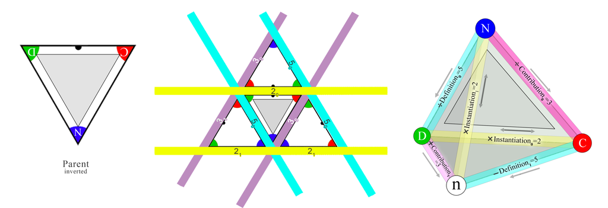

Yet this apparent contradiction resolves elegantly when we expand our view into three dimensions, forming a complete tetrahedron (right image). In this fully realized tetrahedral form, the two segments of the “5” axis merge into a single coherent vector. Simultaneously, the red (*C*), green (*D*), and blue (*N*) points merge into a unified fourth point, represented by the central white dot. What was originally the parent’s blue *N*-state thus transforms into a new white *N*-state. This new white point inherently contains all RGB components and therefore simultaneously functions as *Negotiation* (*N*-blue) relative to the red and green corners, as *Contribution* (*C*-red) relative to the blue and green corners, and as *Definition* (*D*-green) relative to the blue and red corners.

$CHILD_{\text{forward}} + CHILD_{\text{reverse}} = 2 \times PARENT$

Philosophically, this happens because the child is a child to its parent, but it is also a parent itself, resulting in two parents.

Interestingly, two tetrahedrons converge to π, yet also create a perfect cube while π defines the shape of a sphere. At first glance, the relationship between the tetrahedron, the cube, and the sphere seems ironic. A cube and a sphere are eternally separated by the transcendental π, proof that a perfect cube can never precisely transform into a perfect sphere. This impossibility arises because π, the constant defining the relationship between linear and curved geometries, is transcendental and irrational. Yet intriguingly, two tetrahedrons, each Tholonically valued at $\frac{\pi}{2}$, combine perfectly to form a cube, explicitly assigning to the cube a Tholonic value of π. Thus, even as two perfectly rational tetrahedrons merge seamlessly into a cube, their Tholonic identity encodes the inherent impossibility of its perfect transformation.

However, beyond irony, this relationship offers profound philosophical insight. The value of a Tholonic tetrahedron, as revealed through this recursion process, symbolizes an infinite pursuit of **Perfection**, always approaching but never fully attaining it. This reflects precisely how a cube may infinitely approximate a perfect sphere but never fully become one, constrained eternally by π’s transcendental nature. Thus, the impossibility of perfection is intrinsically embedded within the Tholonic tetrahedron itself, reflecting the fundamental truth that perfection can be eternally approached but never fully realized.

Here, again, we see the same interplay of *Perfection*, *Refinement*, and *Growth* that was shown to us previously using the binary values of the vectors and vertices, as described above.

Ultimately, this recursive mathematical structure as well as the associated binary values reveals both mathematical elegance and deep philosophical wisdom, unifying ancient knowledge and modern insight into a coherent vision of existence which exposes some truths on life and reality:

- Perfection is eternally approached but never reached.
- Imperfection creates movement, growth, and infinite refinement.
- Existence can be described as the interplay between internal reflection (*Limitation*) and external interaction (*Contribution*).
- Reality manifests through fractal, recursive self-similarity.
- Wisdom lies not in attaining perfection, but in the endless pursuit of refining oneself toward it.

## The Fibonacci Tholon

The tholonic recursion we have been examining, where each N-state emerges from the interplay of its D and C parents, is not abstract or unique to this model. It is, in fact, the generative rule behind one of the most pervasive numerical sequences in all of nature, the Fibonacci sequence.

Recall the central tholonic relationship:

$$N = D + C$$

where the Negotiation point (the new instance) is the sum of Definition and Contribution. Now consider the Fibonacci recurrence:

$$F(n) = F(n-1) + F(n-2)$$

These are the same statement. In the **Fibonacci Tholon**, each new N-state is the sum of the two preceding states, with the most recent prior state occupying the C (Contribution/Integration) position and the earlier state occupying the D (Definition/Limitation) position. The N-state then becomes the C for the next generation, while the old C becomes the new D, and the recursion continues indefinitely.

| Generation | D (Definition) | C (Contribution) | N (Negotiation) |
| --- | --- | --- | --- |
| 1 | 0 | 1 | 1 |
| 2 | 1 | 1 | 2 |
| 3 | 1 | 2 | 3 |
| 4 | 2 | 3 | 5 |
| 5 | 3 | 5 | 8 |
| 6 | 5 | 8 | 13 |

Each row is a tholon. Each tholon’s N-state becomes the C of the next, and the prior C becomes the new D. The Fibonacci sequence is therefore the trace of a perfectly recursive tholonic chain in which nothing is ever discarded; every prior state continues to participate, just at the next level of resolution.

### The Golden Ratio as Tholonic Self-Similarity

As this recursion continues across successive generations, a remarkable convergence occurs. The ratio of successive N-states:

$$\frac{F(n)}{F(n-1)} \rightarrow \varphi \approx 1.618\ldots$$

approaches the **golden ratio**, φ. This is not merely an interesting mathematical curiosity. It is the tholonic signature of perfect self-similarity, the condition in which the structure of the whole is identical to the structure of any of its parts.

The golden ratio satisfies the unique equation:

$$\varphi = 1 + \frac{1}{\varphi}$$

This means φ is entirely defined by its own reciprocal. The whole and the part stand in the same relationship as the part and the part’s own part, and so on, without end. This is the mathematical definition of tholonic recursion made manifest as a single number. In tholonic terms, the N-state of a perfectly self-similar tholon is structurally identical to the D and C states from which it arose.

We can also express the golden ratio directly in tholonic terms. In the Fibonacci Tholon, φ is precisely that value which, when assigned as the C-state, yields an N-state such that the ratio of whole to part equals the ratio of part to remainder:

$$\frac{N}{C} = \frac{C}{D} = \varphi$$

This is the condition of perfect tholonic self-similarity. Since N = D + C, substituting $N = \varphi \cdot C$ and $C = \varphi \cdot D$ gives:

$$\varphi \cdot C = D + C \quad \Rightarrow \quad \varphi = 1 + \frac{D}{C} = 1 + \frac{1}{\varphi}$$

which is the defining equation of φ, derived purely from the tholonic N = D + C relationship.[^5] Every generation of a golden-ratio tholon looks exactly like every other generation, scaled only by φ. It is, in a very literal sense, a tholon that has achieved perfect balance between Definition and Contribution across infinite recursion. φ is the attractor of tholonic recursion, the value the system converges toward when allowed to recurse freely and without external constraint.

### Why φ Appears in Nature

The golden ratio appears throughout nature, in the arrangement of leaves and seeds (phyllotaxis), the logarithmic spirals of shells and galaxies, the branching patterns of trees and bronchi, and the proportions of bones and coastlines, and this ubiquity is a direct consequence of this tholonic principle.[^6] Any growth process that obeys the rule *new = prior + older prior* (N = D + C) will naturally generate Fibonacci patterns, without any need to “know” the sequence in advance.

Leaves arrange themselves in Fibonacci spirals because this maximizes exposure to light while minimizing overlap, an expression of the tholonic optimization where the N-state emerges from the competition between Contribution (reaching outward) and Definition (maintaining form). A nautilus shell adds each new chamber at a ratio of φ times the previous one because that is the only ratio that allows the new chamber to be added while preserving the exact same shape, making self-similarity the criterion for continued existence.

In none of these cases is the Fibonacci sequence being imposed from outside. It is the natural consequence of a system recursively instantiating the tholonic principle that what is new is always the sum of the two most recent prior states, and that the whole is always the product of its own recursive parts.

In this way, the Fibonacci Tholon is not an application of the tholonic model to mathematics. It is a demonstration that the tholonic principle of N = D + C, applied recursively, is already the generative engine behind the most deeply embedded numerical and geometric patterns in nature.

#### **Key 85:** The Fibonacci sequence is the numerical trace of a perfectly recursive tholonic chain. The golden ratio φ is the attractor to which all such chains converge, the mathematical signature of tholonic self-similarity.

### Two Architectures, Two Attractors

The contrast between the Fibonacci tholon and the π tholon reveals something deeper than two remarkable numerical coincidences. They represent the two fundamental architectures of tholonic recursion.

The Fibonacci tholon is a **closed** recursion. Each generation requires nothing beyond what prior generations produced. No external value ever enters the system. It feeds entirely on its own history, making it a self-contained tholonic chain in which the only resource consumed is the accumulated output of prior steps.

The tholonic recursion that converges to π is an **open** recursion. It is self-referential in that each partial sum builds on those before it, but it also requires a freshly-supplied external parameter at every generation, namely the incrementing values of D and C, which are not derived from prior outputs but arrive from an independent rule outside the chain itself. The system integrates its own history with something new at every step.

These two architectures map directly onto the two fundamental modes of process in nature. Closed recursive processes are governed entirely by internal relationships, such as biological growth, population dynamics, and the spiral packing of seeds. Open recursive processes require a continuing exchange with an external environment, as in oscillation, wave propagation, and any phenomenon that involves periodic interaction with the world outside itself.

That φ is the attractor of closed tholonic recursion and π is the attractor of open tholonic recursion, and that both constants appear universally across every scale of physical reality, is not a coincidence. It is evidence of their sustainability. Sustainability here is not measured by how quickly a human mathematician can compute successive approximations. A stone dropped in still water does not sum a series to determine where the wavefront should be. It arrives at π geometrically and instantaneously, because the circle is the only stable boundary for an expanding wave. A sunflower does not calculate the Fibonacci spiral. It grows into it because φ is the only stable attractor for that mode of closed recursive growth.

This distinction matters. Analog systems can resolve wave interference patterns far faster than digital ones precisely because nature does not iterate toward a solution; it is already the solution. The slow convergence of the Leibniz series is a limitation of the sequential method humans use to approach a value that exists whole and complete in the structure of reality. In tholonic terms, both φ and π are archetypes. They do not need to be computed because they already are.

Any recursive pattern that is not efficient in nature’s terms would not persist. The universality of φ across closed-growth systems and of π across open-periodic systems, from atomic orbitals to galactic spirals, is the selection effect that proves their efficiency. They are the most stable, most efficient, and most sustainable attractors available to each type of tholonic recursion, and the universe demonstrates this at every scale.

#### **Key 86:** The Fibonacci tholon and the π tholon represent the two fundamental architectures of tholonic recursion. The first is closed, drawing each generation only from its own prior history. The second is open, combining its own history with an externally-supplied input at each step. Their respective attractors, φ and π, are the most sustainable patterns of each architecture, as evidenced by their universal appearance across all scales of physical reality.

## Application: Ohm’s Law and the Tholonic Structure

Within the tholons are numerous relationships, and some of these relationships can be visually mapped to the 2D tholon map. For example, we could map the 12 formulas of Ohm’s law to get the following:

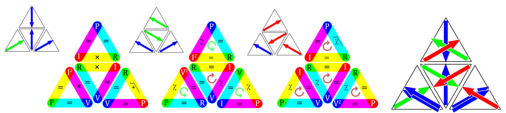

This shows the 4 trigrams that make up a tholon, however, depending on the perspective of view of the tholon, the formulas will be different. There are many ways to view this mapping, but this is perhaps the simplest. Besides the basic 12 formulas, we also see that the trigrams have two “directions”. One direction (the inner circle) is the direction of the formula, but this only applies where division is involved because

[figure not shown]

but

[figure not shown]

. The other direction is an arrow that starts at the initiating value, the point of the N-source, and terminates at the child N-source.

For example, using *P=I×R*, we can see how the mapping assigns *P* as the blue *N-source*, *R* as the green dot of *Definition*, and *I* as the red dot of *Contribution*. This then creates a yellow (additive color of red and green) spectrum between *I* and *R*, which in the case of these formulas, is where the math operators of ×, ÷, √ and the function = exist. This yellow spectrum is that of *Cooperation or Conflict*, so it makes sense that it would also be where we you find × and ÷, and suggests that, in this case at least, cooperation is literally twice as efficient as division, given that the relationships in multiplication-based trigram works in both directions.

You will notice that there are 12 yellow spectrums. These are the only the locations capable of creating a new child N-source, Of those 12, half are the function “=”, and half are operators. Off those 6 operators, 3 are *constructive* (×), 2 are *destructive* (÷), and 1 is *reductive* (√, which is a special case of *destructive*). If we look at the yellow spectrum of only the trigrams where *V* is the blue N-source, as this is the archetype, we see that each of the 3 sets, or each side, always has a pair of function and a single instance of another.

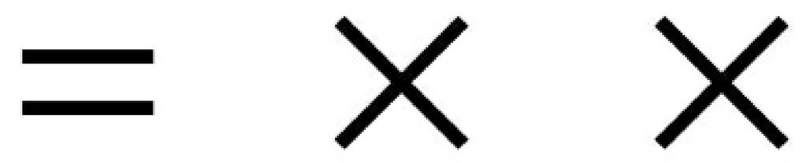

Side 1, Side of *Contribution* as multiplication

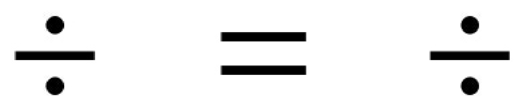

Side 2: side of *Definition* as division.

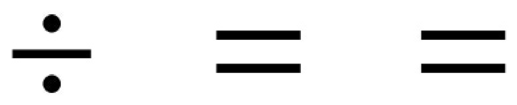

Side 3: side of *Negotiation* as equalization.

This beautifully shows how the primal attributes of *Negotiation*, *Definition*, and *Contribution* continue to reappear in every child and instance. In this case, we can see N, D, and C attributes within each N, D, and C as **C**<sub>NCC</sub>, **D**<sub>DND</sub>, **N**<sub>DNN</sub>. Notice how × and ÷ never share a side, which we would expect to see given that they can only interact via =.

## New Data?

Applying Ohm’s law to the tetrahedron shows some new relationships. Readers who enjoy numbers may find this next (short) section interesting.

We can satisfy all 12 formulas of Ohm’s law as they appear on a tetrahedron, but we can also find some new data now which may appear as useless, or may be meaningful if we know how to use it, as we have claimed that *“There is no useless data, only data we have yet to understand how to use*” and “*All data is valid*”.

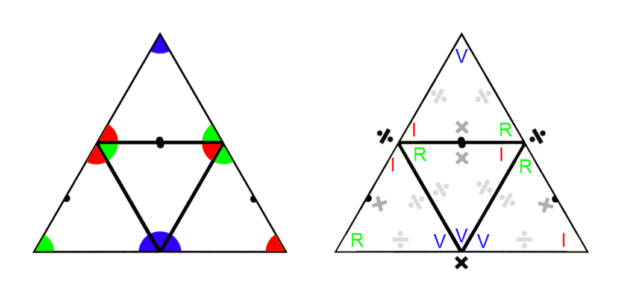

Previously (and in the left-most image above) we saw how the contribution of red divides the green on the right side

[figure not shown]

but constrains the green on the left side

[figure not shown]

. Can we apply these same concepts to other scopes, such as electricity? Does current (*I*) “divide” resistance (*R*) and is resistance (*R*) “constrained” by current (*I*)? Yes, but first we have to recognize that while “constrain” and “divide” have different meanings in their usual context, they have the same mathematical meaning. To describe the function

[figure not shown]

as *X* being *constrained* by *Y*, because *X* is being *defined* by, or measured by *Y*, is not inaccurate, as *X* is indeed being “kept within certain limits” in as far has how it is being measured. We can then say “resistance is defined by current” and “current is limited by resistance”, both of which are technically correct statements.

In the right-most image above we have the 2D tetrahedron map with only *V*, *I*, and *R* values mapped to each trigram, along with the operators (÷, ×). The gray operators are associated with the inner trigrams, and the black operators are associated with the outer trigram.

Ohm’s law states that

[figure not shown]

, so in the image above, all lines that connect *V* to *R* are assigned the ÷ function. The same goes for

[figure not shown]

and *I×R=V*. Note how only N-sources have the functions of ×.

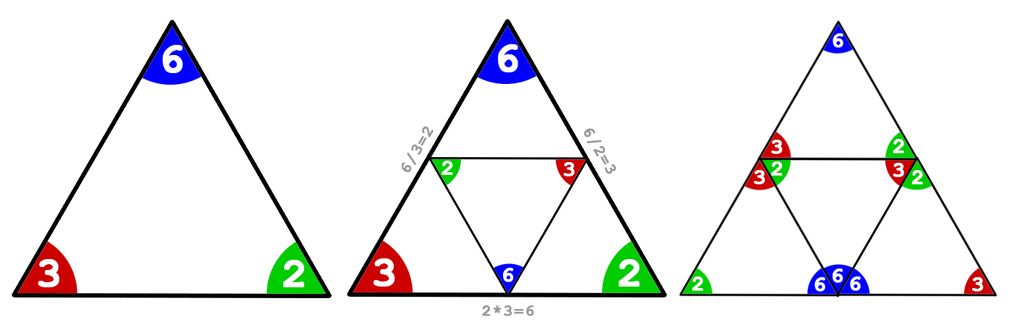

Let’s apply values to these points to make it clearer. Above is a tholon map where *R=2*, *I=3*, *V=6* (and the implied *P=18*). These numbers satisfy the formulas of Ohm’s law as you can see in the image above. These are not arbitrary numbers. They are the smallest numbers that represent the properties of each point, mathematically speaking. Why do we not start with the number 1 then? Because the properties of 1 are the antithesis of creation. 1 represents perfect unity and balance, whereas every number greater that 1 represents separation and imbalance. For example, if we applied the values of 1 to *I* and *R*, then the values of *V* and *P* will also equal 1.

> Every positive integer greater than one can be written uniquely as a product of primes **~ Euclid, 4th century B.C. “The Fundamental Theorem of Arithmetic”**

The number 1 is unlike every other number and stands in a class all by itself:

- It is neither a composite number nor a prime number, though it used to be considered a prime number.
- Any number multiplied by 1 remains that number.
- 1 is its own factorial.
- 1 is its own square and square root, its own cube and cube root, etc.
- 1 is the result of the empty product, as any number multiplied by one is itself.

In fact, from the philosophical perspective of the Neoplatonists, the number 1 is not even considered a number in the traditional sense, but rather the *source* of all numbers.

So, why not start counting with 2 rather than 6? Because we assume that the children of N, when recombined, must equal N.

There are some interesting relationships and values below. I can’t tell you what they mean or represent, but it would be irrational to assume they have no significance without knowing anything more about them. Everything that leads up to these new values is quite reasonable and provable. It is just a matter of discovering where these new values and formulas apply. To explain these new values here would border on sadistic given what the reader has had to suffer through already, and as it qualifies as a book unto itself. However, there are just a couple I would like to share.

If we look at *current* (*I*, red, 3) “dividing” *resistance* (*R*, green, 2), on the right

[figure not shown]

, and apply the operator of division associated with the 6-3 vector, or side, we have 2<sup>2</sup>÷3, which is $1\frac{1}{3}$ (which we’ll call *R<sub>i</sub>*). On the left we have *resistance* (*R*) *constrained* by *current* (*I*)

[figure not shown]

, which is 3<sup>2</sup>÷2, which is $4\frac{1}{2}$ (which we’ll call *I<sub>r</sub>*). Neither number *seems* particularly significant, but if we multiply these numbers together, which we would because they are connected via the “base” of the trigram, the 3-2 vector, which has the operator of ×, we get *R<sub>i</sub>×I<sub>r</sub>*=6, which is the value for *V*, so Ohm’s law has not been broken. Using this same reasoning we can apply this to the three 6s, but as they are on a vector of multiplication, we would say 6<sup>3</sup>, which yields 216 (which we’ll call *V<sub>3</sub>*).

We now have new properties of *R<sub>i</sub>, I<sub>r</sub>, V<sub>3</sub>*. We also know that *R<sub>i</sub>×I<sub>r</sub>=V*. This means we can also say $\frac{V}{R_i}=I_r$ and $\frac{V}{I_r}=R_i$, all in accordance to Ohm’s law. We can also calculate a new value for *P* as *V×I<sub>r</sub>=P*, but this gives us the value 27, which is a different value from *P*=18, so we will call this *P<sub>1</sub>*. Let’s test these values by applying the other formulas and see if we get the correct results. We can apply the formula *I<sub>r</sub><sup>2</sup>×R<sub>i</sub>=P<sub>1</sub>* where we’d expect *P<sub>1</sub>* to equal 27, and it does. Likewise $\frac{P_1}{I_r}=V$.

We have exposed at least 4 new values within the tholon map. Now all we have to do is find out what they mean and where they are applied in the real world. Here are all the values listed.

- *R* = 2
- *I* = 3
- *V* = 6
- *P* = 18
- *R<sub>i</sub>* = $1\frac{1}{3}$
- *I<sub>r</sub>* = 4.5
- *V<sub>3</sub>* = 216
- *P<sub>1</sub>* = 27

Regarding *V<sub>3</sub>*, 216, this is a fascinating number that has a history that goes back to at least Plato, because we know (generally accepted by experts) that 216 is called *Plato’s Number* and was described to Plato by Socrates who said (when explaining how to properly breed humans):

> For the number of the human creature is the first in which root and square multiplications (comprising three dimensions and four limits) of basic numbers which make like and unlike, and which increase and decrease, produce a final result in completely commensurate terms.

*(The word “cubed” was not in use in those days, but 216 is the first (smallest) cube which is the sum of three cubes. It also makes more sense how this might apply to human breeding when you know that back in those days, odd numbers were considered male and even numbers were considered female. Math class back then must have been a lot more interesting.)*

Plato elaborated on this in his “Republic”:

> Now for divine begettings there is a period comprehended by a perfect number, and for mortal by the first in which augmentations dominating and dominated when they have attained to three distances and four limits of the assimilating and the dissimilating, the waxing and the waning, render all things conversable and commensurable with one another, whereof a basal four-thirds wedded to the pempad yields two harmonies at the third augmentation, the one the product of equal factors taken one hundred times, the other of equal length one way but oblong,-one dimension of a hundred numbers determined by the rational diameters of the pempad lacking one in each case, or of the irrational lacking two; the other dimension of a hundred cubes of the triad. And this entire geometrical number is determinative of this thing, of better and inferior births.

The above has been interpreted to mean 6<sup>3</sup>, which Plato alludes to elsewhere, as 6 (considered the number of marriage back then) is the product of female (2) and male (3), and 2<sup>3</sup> × 3<sup>3</sup> = 216. While 216 is the most accepted answer, great thinkers spanning over 2,000 years, such as Aristotle, Proclus, Marsilio Ficino, Gerolamo Cardano, Eduard Zeller, Friedrich Schleiermacher, Paul Tannery, Friedrich Hultsch, and more, have all tried to decipher Plato’s enigmatic text. 216’s fame may even go back as far as Pythagoras, as it is the sum of cubes of the *Pythagorean triple* (3,4,5, hence 3<sup>3</sup> + 4<sup>3</sup> + 5<sup>3</sup>), or even Ancient Babylon.[^7]

Later in history, this pedigree number fell slightly into infamy when John the Apostle declared in Revelations that 666 was the number of the Beast (the beast that comes out of the sea, not the one that comes out of the abyss of the Earth), but also referenced this this number as the the number of man. 216 might have escaped scot-free if John had not specifically said that the number 666 was to be *calculated* (or *counted* depending on translation) to learn its true number.

> Here is a call for wisdom: Let the one who has insight calculate the number of the beast, for it is the number of a man *(ed: or “humanities number”)*, and that number is 666 . **~John, Revelations 13:18 (NIV)**

Mathematicians even classify any prime number that contains the sequence 666 as Belphegor’s Primes, named after one of the seven princes of Hell who helps people make discoveries and seduces them in to thinking they will be become rich as a result. Believe it or not, treasure hunting with demons was a very popular career choice until until the Industrial Age.

Because 216 = 6×6×6, it gained a dubious reputation by association with the Beast of Armageddon and started popping up in some strange places, thanks to humanities generally suspicious nature and love of doom. Fans of the arcane ignore the most likely suggestion that John may have been telling the reader to *add* the numbers together, because in the original Greek it was penned as 600+60+6, and “Six hundred threescore and six” in the most popular King James Bible. However, the odd coincidence that John’s number of man (666), which needed to be “calculated”, has a strong relationship with Socrates’ “number of the human creature” being 6×6×6=216, which also needed to be calculated, is curious… even more curious is why these old timer’s preferred to shroud their message in incomprehensible riddles rather than just tell us the damn number! Ug… philosophers. Regardless, 216’s clout in the religious, mystical, and tin-foil communities holds up today. Just do an Internet search for “216” to see for yourself. Coincidentally, 216 × 10 happens to be the years the procession of the equinox moves through each of the 12 constellations… just sayin’.

The above example is based on only 1 of the 3 sides of a 1<sup>st</sup> generation tholon, and there are countless generations!

[^1]: Maxwell, James Clerk. “**Theory of Heat.**” London: Longmans, Green, and Co., 1871. Chapter 12: “Limitation of the Second Law of Thermodynamics,” pp. 308-309. (The demon was first mentioned in Maxwell’s 1867 letter to Peter Guthrie Tait, and formally published in this 1871 book.)
[^2]: Szilárd, Leó. “**Über die Entropieverminderung in einem thermodynamischen System bei Eingriffen intelligenter Wesen** (On the reduction of entropy in a thermodynamic system by the intervention of intelligent beings).” *Zeitschrift für Physik* 53, no. 11-12 (1929): 840-856. https://doi.org/10.1007/BF01341281
[^3]: Landauer, Rolf. “**Irreversibility and Heat Generation in the Computing Process.**” *IBM Journal of Research and Development* 5, no. 3 (1961): 183-191. https://doi.org/10.1147/rd.53.0183
[^4]: Bennett, Charles H. “**The Thermodynamics of Computation—A Review.**” *International Journal of Theoretical Physics* 21, no. 12 (1982): 905-940. https://doi.org/10.1007/BF02084158
[^5]: This derivation follows directly from the tholonic constraint N = D + C combined with the self-similarity condition N/C = C/D. Setting that common ratio equal to φ and substituting yields φ<sup>2</sup> = φ + 1, whose positive root is φ = (1 + √5)/2 ≈ 1.61803. The golden ratio is thus not an external import but a logical consequence of the tholonic structure itself.
[^6]: The appearance of Fibonacci numbers and φ in biological growth is extensively documented. A rigorous modern treatment is given in Douady, S. and Couder, Y. “**Phyllotaxis as a Physical Self-Organized Growth Process.**” *Physical Review Letters* 68, no. 13 (1992): 2098–2101. For a broader survey, see Livio, Mario. **The Golden Ratio: The Story of Phi, the World’s Most Astonishing Number.** New York: Broadway Books, 2002.
[^7]: Barton, George A. “**On the Babylonian Origin of Plato’s Nuptial Number: on an Old Babylonian Letter Addressed ’to Lushtamar**’”. New Haven: American Oriental Society, 1908. https://www.jstor.org/stable/592627?seq=2#metadata_info_tab_contentst